# Written Assignment 04

Author

Owen Senowitz

Published

October 6, 2024

# Assignment Goal

The goal of this assignment is to demonstrate your understanding of how the concepts from information theory can be used to build machine learning models for predictive tasks.

# 1 Calculating Entropy

The figure below shows a set of eight Scrabble pieces.

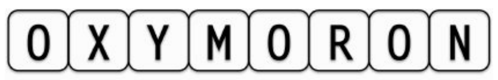

1. What is the entropy (in bits) of the letters in this set?

   To calculate the entropy of the letters in the word **“OXYMORON”**, we follow these steps:

   The letters in “OXYMORON” are: `O, X, Y, M, O, R, O, N`.

   Their frequencies are:
   - `O`: 3 times
   - `X, Y, M, R, N`: 1 time each

   The entropy of the letters in the word **“OXYMORON”** is approximately **2.41 bits**.
2. What would be the reduction in entropy (i.e., the information gain) in bits if we split these letters into two sets, one containing the vowels and the other containing the consonants?
   - `Vowels`: O, O, O
   - `Consonants`: X, Y, M, R, N

   The reduction in entropy (or information gain) after splitting the letters into vowels and consonants is approximately **0.95 bits**.
3. What is the maximum possible entropy (in bits) for a set of eight Scrabble pieces?

   Total Number of Letters: 8 letters

   The maximum possible entropy for a set of eight Scrabble pieces is **3 bits**. This occurs when all eight pieces are distinct and equally likely.
4. In general, which is preferable when you are playing Scrabble: a set of letters with high entropy, or a set of letters with low entropy?

   Having a high entropy set of letters tends to give you a strategic advantage because it maximizes your ability to create different combinations, use special squares, and score well.

# 2 Decision Tree Construction

A convicted criminal who reoffends after release is known as a recidivist. The Table below lists a dataset that describes prisoners released on parole, and whether they reoffended within two years of release.

| ID | Good Behavior | Age Below 30 | Drug Dependent | Recidivist |
| --- | --- | --- | --- | --- |
| 1 | false | true | false | true |
| 2 | false | false | false | false |
| 3 | false | true | false | true |
| 4 | true | false | false | false |
| 5 | true | false | true | true |
| 6 | true | false | false | false |

Prisoners on parole.

This dataset lists six instances where prisoners were granted parole. Each of these instances are described in terms of three binary descriptive features (**Good Behavior**, **Age Below 30**, **Drug Dependent**) and a binary target feature, **Recidivist**. The **Good Behavior** feature has a value of **true** if the prisoner had not committed any infringements during incarceration, the **Age Below 30** has a value of **true** if the prisoner was under 30 years of age when granted parole, and the **Drug Dependent** feature is **true** if the prisoner had a drug addiction at the time of parole. The target feature, **Recidivist**, has a **true** value if the prisoner was arrested within two years of being released; otherwise it has a value of **false**.

1. Using this dataset, construct the decision tree that would be generated by the ID3 algorithm, using entropy-based information gain.

[figure not shown]

2. What prediction will the decision tree generated in part (a) of this question return for the following query?

   **Good Behavior** = false, **Age Below 30** = false, **Drug Dependent** = true

   **Good Behavior** = true, **Age Below 30** = true, **Drug Dependent** = false

# 3 Information Gain

The Table below lists a sample of data from a census.

| ID | Age | Education | Marital Status | Occupation | Annual Income |
| --- | --- | --- | --- | --- | --- |
| 1 | 39 | bachelors | never married | transport | 25K-50K |
| 2 | 50 | bachelors | married | professional | 25K-50K |
| 3 | 18 | high school | never married | agriculture | below 25K |
| 4 | 28 | bachelors | married | professional | 25K-50K |
| 5 | 37 | high school | married | agriculture | 25K-50K |
| 6 | 24 | high school | never married | armed forces | below 25K |
| 7 | 52 | high school | divorced | transport | 25K-50K |
| 8 | 40 | doctorate | married | professional | over 50K |

Census data.

There are four descriptive features and one target feature in this dataset:

- **Age**, a continuous feature listing the age of the individual.
- **Education**, a categorical feature listing the highest education award achieved by the individual (high school, bachelors, doctorate).
- **Marital Status** (never married, married, divorced).
- **Occupation** (transport = works in the transportation industry; professional = doctors, lawyers, etc.; agriculture = works in the agricultural industry; armed forces = is a member of the armed forces).
- **Annual Income**, the target feature with 3 levels (<25K, 25K-50K, >50K).
1. Calculate the **entropy** for this dataset.

   1.29875
2. Calculate the **Gini** index for this dataset.

   0.53125
3. When building a decision tree, the easiest way to handle a continuous feature is to define a threshold around which splits will be made. What would be the optimal threshold to split the continuous **Age** feature (use information gain based on entropy as the feature selection measure)?

# 4 Decision Tree Error Pruning

Shown in the figure below shows a decision tree for predicting heart disease. The descriptive features in this domain describe whether the patient suffers from chest pain (**Chest Pain**) and blood pressure (**Blood Pressure**). The binary target feature is **Heart Disease**. The table below the diagram lists a pruning set from this domain.

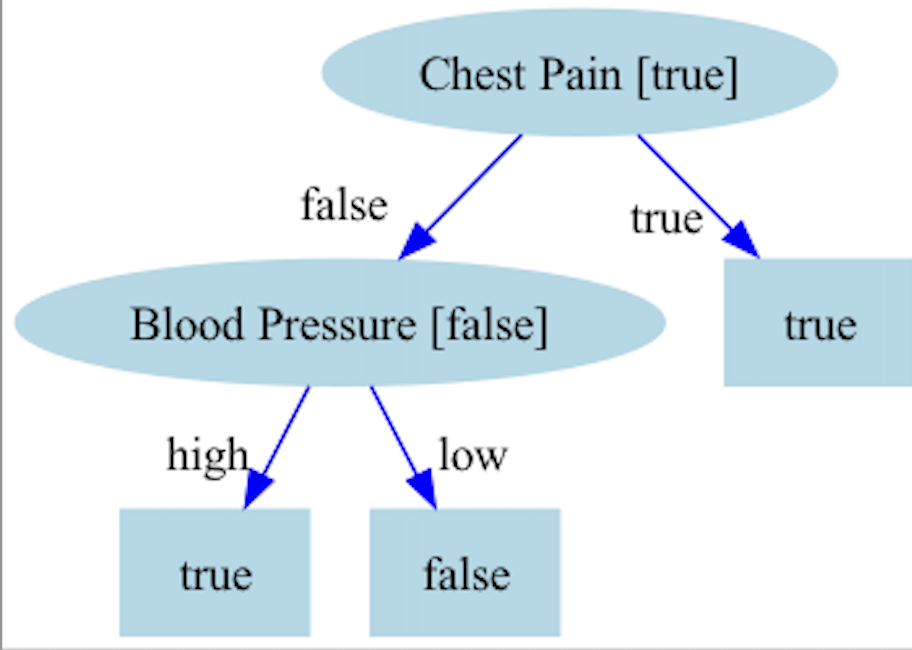

| ID | Chest Pain | Blood Pressure | Heart Disease |
| --- | --- | --- | --- |
| 1 | false | high | false |
| 2 | true | low | true |
| 3 | false | low | false |
| 4 | true | high | true |
| 5 | false | high | false |

Pruning set.

Using the pruning set, apply reduced error pruning to the decision tree. Assume that the algorithm is applied in a bottom-up, left-to-right fashion. For each iteration of the algorithm, indicate the subtrees considered as pruning candidates, explain why the algorithm chooses to prune or leave these subtrees in the tree, and illustrate the tree that results from each iteration.

```
The final pruned decision tree has only one split on Chest Pain. This pruning simplified the tree while maintaining **100% accuracy** on the pruning set, demonstrating effective reduction in complexity without losing predictive performance.
```

# 5 Random Forest

The Table below lists a dataset containing the details of five participants in a heart disease study. The target feature *Risk* describes their risk of heart disease. Each patient is described in terms of four binary descriptive features:

- **Exercise** - how regularly do they exercise
- **Smoker** - do they smoke
- **Obese** - are they overweight
- **Family** - did any of their parents or siblings suffer from heart disease

| ID | Exercise | Smoker | Obese | Family | Risk |
| --- | --- | --- | --- | --- | --- |
| 1 | daily | false | false | yes | low |
| 2 | weekly | true | false | yes | high |
| 3 | daily | false | false | no | low |
| 4 | rarely | true | true | yes | high |
| 5 | rarely | true | true | no | high |

Heart disease study dataset.

As part of the study researchers have decided to create a predictive model to screen participants based on their risk of heart disease. You have been asked to implement this screening model using a random forest. Table below list three bootstrap samples that have been generated from the above dataset.

[output not shown]

Heart disease study dataset bootstrap sample A.

| ID | Smoker | Obese | Risk |
| --- | --- | --- | --- |
| 1 | false | false | low |
| 2 | true | false | high |
| 2 | true | false | high |
| 4 | true | true | high |
| 5 | true | true | high |

Heart disease study dataset bootstrap sample B.

| ID | Obese | Family | Risk |
| --- | --- | --- | --- |
| 1 | false | yes | low |
| 1 | false | yes | low |
| 2 | false | yes | high |
| 4 | true | yes | high |
| 5 | true | no | high |

Heart disease study dataset bootstrap sample C.

1. Using these bootstrap samples create the decision trees that will be in the random forest model (use entropy based information gain as the feature selection criterion).

   Sample A

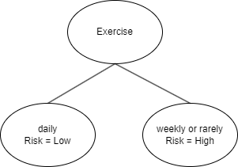

   Sample B

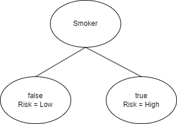

   Sample C

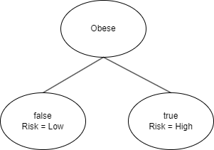

2. Assuming the random forest model you have created uses majority voting, what prediction will it return for the following query:

   Exercise=rarely, Smoker=false, Obese=true, Family=yes

   For the query: Exercise = rarely Smoker = false Obese = true Family = yes

   Decision Tree Predictions:

   Tree A: high Tree B: low Tree C: high

   The random forest model will predict Risk = high for this query.